# Evaluation of PCV7/13 in The Gambia

```r
library(zoo)
library(htmlTable)
library(lme4)
library(lubridate)
library(reshape2)
library(MASS)
library(ggplot2)
source('./R/functions_its.R')
```

## Note on the data

The data we will be using today were collected as part of surveillance activities by the Medical Research Council (MRC) in The Gambia. They were shared by Dr. Grant MacKenzie and should not be re-used outside of this material without his written permission (gmackenzie@mrc.gm). The analyses here were developed by Dr. Nuredin Mohammed in collaboration with Dan Weinberger

## Today’s goal

- Learn how to fit interrupted time series (ITS) models
- Compare models by AIC and select the best model
- Generate counterfactual using ITS model, and calculate rate ratio to evaluate the impact of PCVs

## Background on PCVs and The Gambia

The Gambia is a small country in western Africa, with a population of 2.2 million people. As a lower income country, The Gambia is eligible for and receives support for vaccinatin programs through GAVI, The Vaccine Alliance. GAVI has committed $11.9 million to pneumococcal vaccine programs for the period 2001-2023. With this support, The Gambia introduced PCV7 in 2009. They then replaced PCV7 with PCV13 in 2012, which provides better coverage of the serotypes causing disease in The Gambia.

## Surveillance data

Surveillance for pneumococcal disease and pneumonia started in 2008 and was nested within a demographic and health surveillance system (DHSS). They record pneumonia with several levels of specificity for pneumococcus. The most specific is the isolation of a vaccine-targeted pneumococcal strain from blood or lung sample. The least specific is clinical pneumonia. Hypoxic pneumonia and radiologically-confirmed pneumonia are intermediate.

We are working with monthly time series data for children <5 years of age captured in this system. We have population size data that are fairly accurate due to the regular surveys performed as part of the DHSS.

## Getting started

Save the .csv file in the same directory as this .Rmd file, then read it in using the code below.

```r
# library(haven)
# ds1<-read_dta ('C:/Users/dmw63/Desktop/My documents h/Gambia pneumonia/psp_mthly_epc_08-17.dta')
# ds1<-aggregate(ds1[,-c(1:3)], by=list('yr'=ds1$yr,'mth'=ds1$mth ), FUN=sum)
#  ds2$date<-ymd(paste(ds2$yr,ds2$mth, '01', sep='-'))
#  ds2<-ds2[, c('date','epc','clpneumonia','spnpneumonia','clpnhypox','bronchiol','pcv13st','xray','mppop')]
#  write.csv(ds2,'gambia_u5.csv')
```

Declare the date variable as a date

```r
ds1<- read.csv('./Data/gambia_u5.csv') # or
names(ds1)
```

```
 [1] "X"            "date"         "epc"
 [4] "clpneumonia"  "spnpneumonia" "clpnhypox"
 [7] "bronchiol"    "pcv13st"      "xray"
[10] "mppop"
```

```r
str(ds1)
```

```
'data.frame':   115 obs. of  10 variables:
 $ X           : int  1 2 3 4 5 6 7 8 9 10 ...
 $ date        : chr  "2009-01-01" "2010-01-01" "2011-01-01" "2012-01-01" ...
 $ epc         : int  11 10 10 3 11 13 21 19 11 10 ...
 $ clpneumonia : int  86 78 90 93 86 134 174 166 82 90 ...
 $ spnpneumonia: int  3 3 3 1 2 2 2 2 0 1 ...
 $ clpnhypox   : int  16 2 17 5 1 5 5 0 14 9 ...
 $ bronchiol   : int  24 12 17 4 13 18 28 55 10 34 ...
 $ pcv13st     : int  2 3 1 1 2 0 0 0 0 1 ...
 $ xray        : int  68 66 79 62 76 120 167 161 78 84 ...
 $ mppop       : int  28173 29826 31531 32611 33801 34606 36193 36409 37560 28173 ...
```

Dictionary: * date: date of the month * epc: number of X-ray confirmed pneumonia cases * clpneumonia: clinical pneumonia * spnpneumonia: pneumonia with any pneumococcus isolated from blood or lung * clpnhypox: clinical pneumonia with hypoxia * pcv13st: pneumonia with any PCV13 serotype pneumococcus isolated from blood or lung * bronchiol: brochiolitis (wheezing, X-ray negative) * xray: Number of xrays performed per month * mppop: population size

## Time series plots

Let’s first look at time series plots for various definitions of pneumonia.

The easiest way to do this is to reshape the data into a ‘long’ format and then use facet wrapping with ggplot2

first reshape the data

```r
ds1$date <- as.Date(ds1$date)

ds1 <- ds1[order(ds1$date),]
```

All on the same plot

```r
ds1.m <- reshape2::melt(ds1[,c('date','spnpneumonia','epc','clpnhypox','clpneumonia')], id.vars=c('date'))
```

Separate axes for each. Add a facet wrap

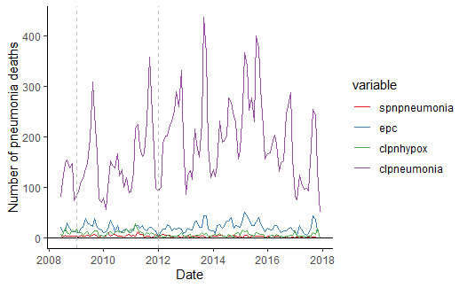

```r
p1 <- ggplot(ds1.m, aes(x=date, y=value, color=variable)) +
      geom_line() +
      ylab("Number of pneumonia deaths") +
      xlab("Date") +
      theme_classic() +
      geom_hline(yintercept=0, col='black', lty=1) +
      scale_color_manual(values = c("#e41a1c", "#377eb8","#4daf4a","#984ea3")) +
      geom_vline(xintercept=as.Date(c('2009-01-01','2012-01-01')), col='gray', lty=2)
p1
```

## Setup variables needed for interrupted time series (ITS) model

Will create disjointed segments

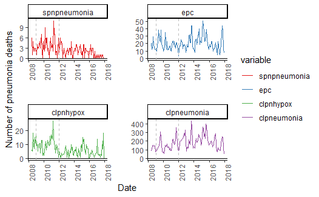

```r
p2 <-p1 +
      facet_wrap(~variable , scales='free') +
      theme(panel.spacing= unit(2,'lines') , axis.text.x=element_text(angle=90))

p2
```

## Step 1: What NOT to do:

ITS with time index variable, dummy variables for post periods, and their interactions –This is way too complicated of a model for 1 year of pre-vaccine data. Remembe: the counterfactual is based only on what happens during the pre-vaccine periods.

We will first work on the X-ray confirmed pneumonia (epc).

```r
# Time index variable to control for long term linear trend
ds1$index <- 1:nrow(ds1)
ds1$index <- ds1$index/max(ds1$index) # Scale index variable so it varies from 0-1
ds1$index
```

```
  [1] 0.008695652 0.017391304 0.026086957 0.034782609
  [5] 0.043478261 0.052173913 0.060869565 0.069565217
  [9] 0.078260870 0.086956522 0.095652174 0.104347826
 [13] 0.113043478 0.121739130 0.130434783 0.139130435
 [17] 0.147826087 0.156521739 0.165217391 0.173913043
 [21] 0.182608696 0.191304348 0.200000000 0.208695652
 [25] 0.217391304 0.226086957 0.234782609 0.243478261
 [29] 0.252173913 0.260869565 0.269565217 0.278260870
 [33] 0.286956522 0.295652174 0.304347826 0.313043478
 [37] 0.321739130 0.330434783 0.339130435 0.347826087
 [41] 0.356521739 0.365217391 0.373913043 0.382608696
 [45] 0.391304348 0.400000000 0.408695652 0.417391304
 [49] 0.426086957 0.434782609 0.443478261 0.452173913
 [53] 0.460869565 0.469565217 0.478260870 0.486956522
 [57] 0.495652174 0.504347826 0.513043478 0.521739130
 [61] 0.530434783 0.539130435 0.547826087 0.556521739
 [65] 0.565217391 0.573913043 0.582608696 0.591304348
 [69] 0.600000000 0.608695652 0.617391304 0.626086957
 [73] 0.634782609 0.643478261 0.652173913 0.660869565
 [77] 0.669565217 0.678260870 0.686956522 0.695652174
 [81] 0.704347826 0.713043478 0.721739130 0.730434783
 [85] 0.739130435 0.747826087 0.756521739 0.765217391
 [89] 0.773913043 0.782608696 0.791304348 0.800000000
 [93] 0.808695652 0.817391304 0.826086957 0.834782609
 [97] 0.843478261 0.852173913 0.860869565 0.869565217
[101] 0.878260870 0.886956522 0.895652174 0.904347826
[105] 0.913043478 0.921739130 0.930434783 0.939130435
[109] 0.947826087 0.956521739 0.965217391 0.973913043
[113] 0.982608696 0.991304348 1.000000000
```

```r
# Monthly dummy variables to control for seasonality
ds1$month <- as.factor(month(ds1$date)) # Extract month number, define as factor
table(ds1$month)
```

```
 1  2  3  4  5  6  7  8  9 10 11 12
 9  9  9  9  9 10 10 10 10 10 10 10
```

```r
# 3 dummy variables for post periods
ds1$post1 <- 0
ds1$post2 <- 0
ds1$post3 <- 0
ds1$post1[ds1$date >= "2009-08-01" & ds1$date < "2010-08-01"] <- 1 # First year of PCV7
ds1$post2[ds1$date >= "2010-08-01" & ds1$date < "2012-05-01"] <- 1 # Post-PCV7 until PCV13 intro
ds1$post3[ds1$date >= "2012-05-01"] <- 1 # Post-PCV13
# View(ds1)
# Offset
ds1$log_pop <- log(ds1$mppop + 0.5)

time_points1 <- unique(ds1$date)
```

summarize model output

```r
# Negative binomial model
# Outcome: X-ray confirmed pneumonia (epc)
mod1.epc <- glm.nb(epc ~ month + index +
                     post1 + post2 + post3 +  # Post period
                     index*post1 + index*post2 + post3*index + # Interactions
                     offset(log_pop), # Population offset
                   data=ds1)
```

generate the counterfactuals

```r
# Summary
summary(mod1.epc)
```

```
Call:
glm.nb(formula = epc ~ month + index + post1 + post2 + post3 +
    index * post1 + index * post2 + post3 * index + offset(log_pop),
    data = ds1, init.theta = 12.83360949, link = log)

Deviance Residuals:
    Min       1Q   Median       3Q      Max
-2.7411  -0.7003  -0.1137   0.5870   2.5968

Coefficients:
            Estimate Std. Error z value Pr(>|z|)
(Intercept) -8.08222    0.25114 -32.182  < 2e-16 ***
month2       0.21591    0.18484   1.168 0.242772
month3       0.62899    0.17814   3.531 0.000414 ***
month4       0.71709    0.17743   4.041 5.31e-05 ***
month5       0.67189    0.17790   3.777 0.000159 ***
month6       0.52072    0.17653   2.950 0.003180 **
month7       0.41459    0.17840   2.324 0.020133 *
month8       0.52540    0.17754   2.959 0.003083 **
month9       0.93729    0.17201   5.449 5.07e-08 ***
month10      0.71586    0.17400   4.114 3.89e-05 ***
month11      0.38476    0.17844   2.156 0.031069 *
month12      0.11002    0.18348   0.600 0.548768
index        4.46715    2.82374   1.582 0.113650
post1        0.50629    0.67600   0.749 0.453889
post2        0.06951    0.55574   0.125 0.900465
post3        0.62481    0.28255   2.211 0.027015 *
index:post1 -5.76752    4.44442  -1.298 0.194390
index:post2 -4.74174    3.19686  -1.483 0.138008
index:post3 -5.13739    2.83690  -1.811 0.070154 .
---
Signif. codes:  0 ‘***’ 0.001 ‘**’ 0.01 ‘*’ 0.05 ‘.’ 0.1 ‘ ’ 1

(Dispersion parameter for Negative Binomial(12.8336) family taken to be 1)

    Null deviance: 192.03  on 114  degrees of freedom
Residual deviance: 115.21  on  96  degrees of freedom
AIC: 804.06

Number of Fisher Scoring iterations: 1

              Theta:  12.83
          Std. Err.:  2.79

 2 x log-likelihood:  -764.06
```

```r
AIC(mod1.epc)
```

```
[1] 804.0604
```

```r
ds.mod1 <- ds1
# Model-fitted number of pneumonia cases
ds.mod1$pred.epc <- predict(mod1.epc, type='response', newdata=ds.mod1)
```

Plot the model fit

```r
# Generate the counterfactual number of pneumonia cases
ds1.counter <- ds.mod1
ds1.counter$post1 <- 0
ds1.counter$post2 <- 0
ds1.counter$post3 <- 0
# View(ds1.counter)

ds.mod1$pred.epc.cf <- predict(mod1.epc, type='response', newdata=ds1.counter) # newdata is now "ds1.counter"

# Calculate a rate ratio (i.e., Ratio of model-fitted vs. counterfactual number of pneumonia cases)
ds.mod1$rr1.epc <- ds.mod1$pred.epc / ds.mod1$pred.epc.cf
```

This counterfactual (red line in the plot) looks kind of crazy. Part of the problem is that we only have 1 year of pre vaccine data so can’t really get a good estimate of the long-term trend.

Let’s ditch trend and interaction between trend and post-period. We will then just be using the dummy variables to test whether the *average* number of cases changes.

## ITS with dummy variables for post periods

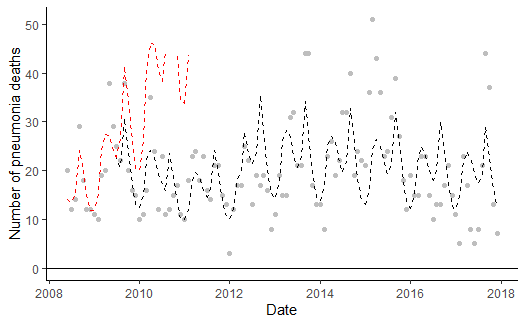

```r
p4 <- ggplot(ds.mod1, aes(x=date, y=epc)) +
      geom_point( pch=16,col='gray') +
      ylab("Number of pneumonia deaths") +
      xlab("Date") +
      theme_classic() +
      geom_line(data=ds.mod1, aes(x=date, y=pred.epc), col='black', lty=2) +
      geom_line(data=ds.mod1, aes(x=date, y=pred.epc.cf), col='red', lty=2) +
      ylim(0, max(ds.mod1$epc))+
      geom_hline(yintercept=0, col='black', lty=1)
p4
```

We can use some functions to make it easier to compare different models

```r
# Negative binomial model
# Outcome: X-ray confirmed pneumonia (epc)
mod2.epc <- glm.nb(epc ~ month +
                     post1 + post2 + post3 +
                     offset(log_pop),
                   data=ds1)

# Model summary
summary(mod2.epc)
```

```
Call:
glm.nb(formula = epc ~ month + post1 + post2 + post3 + offset(log_pop),
    data = ds1, init.theta = 11.35473917, link = log)

Deviance Residuals:
     Min        1Q    Median        3Q       Max
-3.01364  -0.70427  -0.08226   0.57943   2.46781

Coefficients:
            Estimate Std. Error z value Pr(>|z|)
(Intercept) -7.77986    0.16851 -46.168  < 2e-16 ***
month2       0.22236    0.19070   1.166 0.243619
month3       0.62670    0.18409   3.404 0.000663 ***
month4       0.71403    0.18296   3.903 9.51e-05 ***
month5       0.71043    0.18301   3.882 0.000104 ***
month6       0.53395    0.18158   2.941 0.003276 **
month7       0.42614    0.18310   2.327 0.019947 *
month8       0.51604    0.18183   2.838 0.004540 **
month9       0.91856    0.17710   5.187 2.14e-07 ***
month10      0.69826    0.17947   3.891 1.00e-04 ***
month11      0.36981    0.18404   2.009 0.044492 *
month12      0.09368    0.18908   0.495 0.620297
post1       -0.02598    0.14833  -0.175 0.860949
post2       -0.31700    0.13359  -2.373 0.017646 *
post3       -0.14686    0.11093  -1.324 0.185567
---
Signif. codes:  0 ‘***’ 0.001 ‘**’ 0.01 ‘*’ 0.05 ‘.’ 0.1 ‘ ’ 1

(Dispersion parameter for Negative Binomial(11.3547) family taken to be 1)

    Null deviance: 178.27  on 114  degrees of freedom
Residual deviance: 115.53  on 100  degrees of freedom
AIC: 804.9

Number of Fisher Scoring iterations: 1

              Theta:  11.35
          Std. Err.:  2.36

 2 x log-likelihood:  -772.895
```

```r
AIC(mod1.epc, mod2.epc)
```

|  | df | AIC |
| --- | --- | --- |
| mod1.epc | 20 | 804.0604 |
| mod2.epc | 16 | 804.8953 |

The AIC score is not notably different than the model with the interactions, and it looks a lot cleaner.

## Other things we could think about

While we don’t have RSV data, we do have bronchiolitis data. Bronchiolitis is mostly caused by RSV, so this is a *syndromic* indictor for RSV activity. And volume of X-rays performed could provide an adjustment for the numbers of kids coming in with both severe and less severe respiratory symptoms.

## Various definitions of pneumonia

Let’s look at various outcomes. To do this efficiently, let’s write a *function*. This function will basically take the code from above and make it so that we can swap out different components easily. The name of our function is “step_func”.

(While we are at it, we want to be able to generate confidence intervals for different values. We can do this by simulation by drawing random samples from the variance-covariance matrix of the regression model. Don’t worry about the details, it is all done for you in the function.)

In the function, we will use a Poisson regression (rather than negative binomial).

In one of the models, we will use linear *splines* for post periods, instead of dummy variables.

Ok now we are ready to call our model.

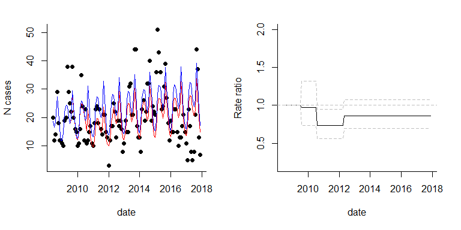

```r
mod2.epc.alt <- step_func(ds=ds1, outcome_name='epc', denom='mppop', mod='negbin', other.covars='none')

plot.step.func(mod2.epc.alt)
```

This suggests that the best model by AIC adjusts for XRays. Models 1b,c,e are similar by AIC, all give similar RR estimates We are using a negative binomial model here

```r
#-----*-----*-----*-----*-----*-----*-----#
# epc (X-ray confirmed pneumonia)
#-----*-----*-----*-----*-----*-----*-----#

# 5 models controllling for different sets of covariates
# NOTE: all models control for seasonality (by monthly dummy variables) and population (offset)

mod1a <- step_func(ds=ds1, outcome_name='epc', denom='mppop', mod='negbin', other.covars='none')

mod1b <- step_func(ds=ds1, outcome_name='epc', denom='mppop', mod='negbin', other.covars='xray')

mod1c <- step_func(ds=ds1, outcome_name='epc', denom='mppop', mod='negbin', other.covars=c('xray','time_index'))

mod1d <- step_func(ds=ds1, outcome_name='epc', denom='mppop', mod='negbin', other.covars=c('bronchiol','time_index') )

mod1e <- spline_func(ds=ds1,outcome_name='epc', denom='mppop',other.covars= c('xray'), mod='negbin' )

# Extract results
rr <- t(sapply(list(mod1a,mod1b, mod1c,mod1d,mod1e), '[[','rr.q.post'))
rr
```

```
          2.5%       50%     97.5%
[1,] 0.6959241 0.8612894 1.0564129
[2,] 0.4411275 0.5300962 0.6456936
[3,] 0.4578821 0.6376054 0.8835717
[4,] 0.9055350 1.2691232 1.7845929
[5,] 0.4256714 0.5124215 0.6389948
```

```r
aic <- t(sapply(list(mod1a,mod1b, mod1c,mod1d,mod1e), '[[','aic1'))
aic
```

```
         [,1]     [,2]    [,3]     [,4]     [,5]
[1,] 804.8953 741.8484 741.846 782.5908 740.8267
```

```r
#dispersion <- t(sapply(list(mod1a,mod1b, mod1c,mod1d,mod1e), '[[','overdispersion'))
#dispersion
```

Model E does best–adjusts for pneumococcal pneumonia (pcv13st is a subset of pneumococcal pneumonia). So we are effectively testing whether pneumonia caused by PCV13 serotypes declines in relation to the overall change in pneumococcal pneumonia. We can stick with Poisson model here.

```r
#-----*-----*-----*-----*-----*-----*-----*-----*-----#
# pcv13st (Pneumonia caused by PCV13 serotypes)
#-----*-----*-----*-----*-----*-----*-----*-----*-----#

mod2a <- step_func(ds=ds1,outcome_name='pcv13st', denom='mppop', mod='pois')
mod2b <- step_func(ds=ds1,outcome_name='pcv13st', denom='mppop', mod='pois', other.covars='xray')
mod2c <- step_func(ds=ds1,outcome_name='pcv13st', denom='mppop', mod='pois', other.covars='spnpneumonia')
mod2d <- step_func(ds=ds1,outcome_name='pcv13st', denom='mppop', mod='pois', other.covars= c('time_index'))
mod2e <- spline_func(ds=ds1,outcome_name='pcv13st', denom='mppop', mod='pois', other.covars= c('spnpneumonia'))

rr <- t(sapply(list(mod2a,mod2b, mod2c,mod2d,mod2e), '[[','rr.q.post'))
rr
```

```
          2.5%       50%     97.5%
[1,] 0.1357116 0.2146112 0.3402244
[2,] 0.1208257 0.2052513 0.3502160
[3,] 0.2150201 0.3568651 0.5546458
[4,] 0.5737187 1.7341252 4.9558060
[5,] 0.0716798 0.1640525 0.3938216
```

```r
aic <- t(sapply(list(mod2a,mod2b, mod2c,mod2d,mod2e), '[[','aic1'))
aic
```

```
         [,1]     [,2]     [,3]  [,4]     [,5]
[1,] 333.1439 335.1236 282.9319 318.3 278.0835
```

```r
dispersion <- t(sapply(list(mod2a,mod2b, mod2c,mod2d,mod2e), '[[','overdispersion'))
dispersion
```

```
         [,1]     [,2]      [,3]      [,4]      [,5]
[1,] 1.143092 1.154434 0.6272447 0.9844981 0.5782709
```

mod3c and mod3d are the best models. They give very different answers. Might consider looking at the counterfactual to see if anything ooks funny

```r
#-----*-----*-----*-----*-----*-----*-----*-----*-----#
# spnpneumonia (Pneumococcal pneumonia)
#-----*-----*-----*-----*-----*-----*-----*-----*-----#

mod3a <- step_func(ds=ds1, outcome_name='spnpneumonia', denom='mppop', mod='pois')
mod3b <- step_func(ds=ds1, outcome_name='spnpneumonia', denom='mppop', mod='pois', other.covars='xray' )
mod3c <- step_func(ds=ds1, outcome_name='spnpneumonia', denom='mppop', mod='pois', other.covars= c('time_index'))
mod3d <- spline_func(ds=ds1,outcome_name='spnpneumonia', denom='mppop', mod='pois', other.covars= c('xray'))

rr <- t(sapply(list(mod3a,mod3b, mod3c,mod3d), '[[','rr.q.post'))
rr
```

```
          2.5%       50%     97.5%
[1,] 0.3179287 0.4487063 0.6191565
[2,] 0.2322678 0.3572508 0.5424570
[3,] 0.8508148 1.7134987 3.5359312
[4,] 0.1021356 0.1680059 0.2804869
```

```r
aic <- t(sapply(list(mod3a,mod3b, mod3c,mod3d), '[[','aic1'))
aic
```

```
         [,1]    [,2]     [,3]     [,4]
[1,] 432.9871 431.209 417.2938 417.5682
```

```r
dispersion <- t(sapply(list(mod3a,mod3b, mod3c,mod3d), '[[','overdispersion'))
dispersion
```

```
         [,1]     [,2]    [,3]     [,4]
[1,] 1.306166 1.281197 1.14064 1.143411
```

4d: Spline model adjusting for xrays best

```r
#-----*-----*-----*-----*-----*-----*-----*-----*-----#
# clpnhypox (Hypoxic pneumonia)
#-----*-----*-----*-----*-----*-----*-----*-----*-----#

mod4a<-step_func(ds=ds1,outcome_name='clpnhypox', denom='mppop', mod='negbin')
mod4b<-step_func(ds=ds1,outcome_name='clpnhypox', denom='mppop', mod='negbin', other.covars='xray')
mod4c<-step_func(ds=ds1,outcome_name='clpnhypox', denom='mppop', mod='negbin', other.covars='time_index')
mod4d<-spline_func(ds=ds1,outcome_name='clpnhypox', denom='mppop', mod='negbin', other.covars='xray')

rr<-t(sapply(list(mod4a, mod4b, mod4c, mod4d), '[[','rr.q.post'))
rr
```

```
          2.5%       50%     97.5%
[1,] 0.2616112 0.3709381 0.5296990
[2,] 0.1587977 0.2317268 0.3613412
[3,] 0.2401505 0.4772578 0.9339713
[4,] 0.1990441 0.2977359 0.4373227
```

```r
aic<-t(sapply(list(mod4a,mod4b, mod4c,mod4d), '[[','aic1'))
aic
```

```
         [,1]     [,2]     [,3]     [,4]
[1,] 651.4746 637.9001 652.8807 619.2244
```

```r
dispersion<-t(sapply(list(mod4a,mod4b, mod4c,mod4d), '[[','overdispersion'))
dispersion
```

```
         [,1]     [,2]     [,3]     [,4]
[1,] 1.233434 1.226864 1.246267 1.228565
```

Best model (D) adjusts for Xrays and uses spline functions to connect post vaccine periods. The best model is not overdiserpsed, so stick with Poisson. (mod5a and mod5c are clearly overdispersed, so we can try negative binomial.)

## RRs by the best model for each outcome

```r
#-----*-----*-----*-----*-----*-----*-----*-----*-----#
# clpneumonia (Clinical pneumonia)
#-----*-----*-----*-----*-----*-----*-----*-----*-----#

mod5a<-step_func(ds=ds1,outcome_name='clpneumonia', denom='mppop', mod='pois')
mod5b<-step_func(ds=ds1,outcome_name='clpneumonia', denom='mppop', mod='pois', other.covars='xray')
mod5c<-step_func(ds=ds1,outcome_name='clpneumonia', denom='mppop', mod='pois', other.covars='time_index')
mod5d<-spline_func(ds=ds1,outcome_name='clpneumonia', denom='mppop', mod='pois', other.covars='xray')

rr<-t(sapply(list(mod5a, mod5b, mod5c,mod5d), '[[','rr.q.post'))
rr
```

```
          2.5%       50%     97.5%
[1,] 1.1765886 1.2389649 1.2991176
[2,] 0.6488579 0.6881702 0.7317309
[3,] 1.8379971 1.9989109 2.1564009
[4,] 0.6085050 0.6453378 0.6818880
```

```r
aic<-t(sapply(list(mod5a,mod5b,mod5c,mod5d), '[[','aic1'))
aic
```

```
         [,1]     [,2]     [,3]     [,4]
[1,] 2837.977 931.5717 2607.298 891.1162
```

```r
dispersion<-t(sapply(list(mod5a,mod5b, mod5c,mod5d), '[[','overdispersion'))
dispersion
```

```
         [,1]     [,2]     [,3]     [,4]
[1,] 20.10342 1.029655 17.95618 0.621014
```

Or express as percent decline. We can use ‘htmlTable’ to generate a nice looking outcome

```r
# Select the best model for each outcome
best.models <- list(mod1e, mod2e, mod3d, mod4b, mod5b)

# Create a table of RRs generated by the "best" model
rr.all <- round(t(sapply(best.models, '[[','rr.q.post')),2)
row.names(rr.all) <- c('X-ray confirmed pneumonia','PCV13 serotypes','Pneumococcal pneumonia', 'Hypoxic pneumonia', 'Clinical pneumonia' )
rr.all
```

```
                          2.5%  50% 97.5%
X-ray confirmed pneumonia 0.43 0.51  0.64
PCV13 serotypes           0.07 0.16  0.39
Pneumococcal pneumonia    0.10 0.17  0.28
Hypoxic pneumonia         0.16 0.23  0.36
Clinical pneumonia        0.65 0.69  0.73
```

This demonstrates that the greatest declines were seen for pneumonia where there was a pneumococcus detected, which is what we would expect. Hypoxic pneumonia, a very severe form, also exhibited large declines. X-ray confirmed pneumonia is intermediate. And clinical pneumonia, the least specific of the definitions, exhibits the smallest declines.

## Plot the best model for each outcome

```r
pct.decline.all <- 100*(1-rr.all)

PercentDecline <- paste0(pct.decline.all[,2],
       '%, (',
       pct.decline.all[,3] ,'%,',pct.decline.all[,1]  ,'%)'    )

htmlTable(cbind(row.names(pct.decline.all), PercentDecline))
```

|  | PercentDecline |
| --- | --- |
| X-ray confirmed pneumonia | 49%, (36%,57%) |
| PCV13 serotypes | 84%, (61%,93%) |
| Pneumococcal pneumonia | 83%, (72%,90%) |
| Hypoxic pneumonia | 77%, (64%,84%) |
| Clinical pneumonia | 31%, (27%,35%) |

## Summary

For many of the outcomes, adjusting for X-Ray volume per month substantially cleaned up the estimates. This largely follows a pattern that we would expect, with larger declines for more specific outcomes. The decision about whether to adjust for linear time trend is tricky. AIC suggests that it improves the model fit in some instances. However, it also leads to some weird non-credible estimates in some instances as well.